# Analyzing Language Simplification in Alzheimer’s Disease Using Basic NLP Methods

Farhad

April 2026

## 1. Load Libraries

This section loads only the required packages for data wrangling, tokenization, string cleaning, and plotting.

```r
# load tidyverse for data manipulation and pipes
library(tidyverse)

# load tidytext for tokenization and stopword handling
library(tidytext)

# load stringr for regex-based text cleaning
library(stringr)

# load ggplot2 for visualizations
library(ggplot2)
```

## 2. Read and Parse `.cha` Files

```r
# set preferred data folder provided by user
preferred_root <- "/Users/dr.farhadshah/Library/CloudStorage/OneDrive-TempleUniversity/Shah_RData/Week8_NLPClass/data"

# set fallback data folder for portable project execution
fallback_root <- "data"

# select preferred folder when it exists, otherwise use fallback folder
root_folder <- ifelse(dir.exists(preferred_root), preferred_root, fallback_root)

# collect all .cha files recursively
cha_files <- list.files(
  path = root_folder,            # start from data/
  pattern = "\\.cha$",           # keep only .cha files
  recursive = TRUE,              # search all nested folders
  full.names = TRUE              # return full file paths
)

# stop early if no transcript files are found
if (length(cha_files) == 0) {
  stop("No .cha files were found under data/. Please check the folder path.")
}

# define a helper that extracts participant lines and collapses them
extract_chi_text <- function(file_path) {
  # read all lines from one transcript file
  lines <- readLines(file_path, warn = FALSE, encoding = "UTF-8")

  # keep participant speech lines that start with *CHI: or *PAR: (case-insensitive)
  chi_lines <- lines %>%
    str_subset(regex("^\\s*\\*(CHI|PAR):", ignore_case = TRUE))

  # fallback to all lines if no participant lines are found
  if (length(chi_lines) == 0) {
    chi_lines <- lines
  }

  # remove leading speaker prefix from each kept line
  chi_lines <- chi_lines %>%
    str_replace(regex("^\\s*\\*(CHI|PAR):\\s*", ignore_case = TRUE), "")

  # collapse all participant lines into one text string
  chi_text <- chi_lines %>%
    paste(collapse = " ") %>%
    str_squish()

  # return collapsed participant text
  chi_text
}

# build one row per file with metadata and extracted participant text
transcripts <- tibble(file_path = cha_files) %>%
  mutate(
    file_name = basename(file_path),  # store file name

    group = case_when(  # derive group from path (case-insensitive)
      str_detect(file_path, regex("control", ignore_case = TRUE)) ~ "control",
      str_detect(file_path, regex("dementia", ignore_case = TRUE)) ~ "dementia",
      TRUE ~ "unknown"
    ),

    task = case_when(  # derive task from path (case-insensitive)
      str_detect(file_path, regex("cookie", ignore_case = TRUE)) ~ "cookie",
      str_detect(file_path, regex("fluency", ignore_case = TRUE)) ~ "fluency",
      str_detect(file_path, regex("recall", ignore_case = TRUE)) ~ "recall",
      str_detect(file_path, regex("sentence", ignore_case = TRUE)) ~ "sentence",
      TRUE ~ "other"
    ),

    full_text = map_chr(file_path, extract_chi_text)  # extract participant speech
  ) %>%
  filter(group %in% c("control", "dementia")) %>%  # keep only relevant groups
  filter(!is.na(full_text)) %>%  # remove NA text
  filter(str_trim(full_text) != "")  # remove empty transcripts

# fallback if parsing removed everything (extra safety layer)
if (nrow(transcripts) == 0) {

  message("No CHI/PAR lines found — falling back to full transcript text.")

  transcripts <- tibble(file_path = cha_files) %>%
    mutate(
      file_name = basename(file_path),  # store file name

      group = case_when(
        str_detect(file_path, regex("control", ignore_case = TRUE)) ~ "control",
        str_detect(file_path, regex("dementia", ignore_case = TRUE)) ~ "dementia",
        TRUE ~ "unknown"
      ),

      task = case_when(
        str_detect(file_path, regex("cookie", ignore_case = TRUE)) ~ "cookie",
        str_detect(file_path, regex("fluency", ignore_case = TRUE)) ~ "fluency",
        str_detect(file_path, regex("recall", ignore_case = TRUE)) ~ "recall",
        str_detect(file_path, regex("sentence", ignore_case = TRUE)) ~ "sentence",
        TRUE ~ "other"
      ),

      full_text = map_chr(file_path, ~ paste(readLines(.x, warn = FALSE), collapse = " "))  # use full file text
    ) %>%
    filter(group %in% c("control", "dementia")) %>%
    filter(str_trim(full_text) != "")
}

# print preview of parsed transcript table
transcripts %>%
  select(file_name, group, task, full_text) %>%
  head(5)
```

```
## # A tibble: 5 × 4
##   file_name group   task   full_text
##   <chr>     <chr>   <chr>  <chr>
## 1 002-0.cha control cookie "the scene is <in the> [/] in the kitchen . \u001537…
## 2 002-1.cha control cookie "oh I see the sink is running over . \u00153044_5547…
## 3 002-2.cha control cookie "&-um a boy and a girl are in the kitchen with their…
## 4 002-3.cha control cookie "okay . [+ exc] it was summertime and mother and the…
## 5 006-2.cha control cookie "&=clears:throat wait (un)til I put my glasses on . …
```

## 3. Clean Text

This section normalizes text by lowercasing, removing punctuation and numbers, and trimming extra spaces while keeping filler words like `um` and `uh`.

```r
# define a helper function for simple regex-based text cleaning
clean_transcript_text <- function(text) {
  text %>%
    str_to_lower() %>%                       # convert all text to lowercase
    str_replace_all("[^a-z\\s]", " ") %>% # remove punctuation and numbers
    str_replace_all("\\s+", " ") %>%      # replace repeated spaces with one space
    str_trim()                               # trim spaces at the edges
}

# apply cleaning to each transcript
transcripts_clean <- transcripts %>%
  mutate(clean_text = map_chr(full_text, clean_transcript_text))

# remove any rows that become empty after cleaning
transcripts_clean <- transcripts_clean %>%
  filter(clean_text != "")

# stop if cleaned data is empty
if (nrow(transcripts_clean) == 0) {
  stop("All transcripts became empty after cleaning. Please inspect input text.")
}

# print preview of cleaned data
transcripts_clean %>%
  select(file_name, group, task, clean_text) %>%
  head(5)
```

```
## # A tibble: 5 × 4
##   file_name group   task   clean_text
##   <chr>     <chr>   <chr>  <chr>
## 1 002-0.cha control cookie the scene is in the in the kitchen the mother is wip…
## 2 002-1.cha control cookie oh i see the sink is running over i see the stool is…
## 3 002-2.cha control cookie um a boy and a girl are in the kitchen with their mo…
## 4 002-3.cha control cookie okay exc it was summertime and mother and the childr…
## 5 006-2.cha control cookie clears throat wait un til i put my glasses on exc oh…
```

## 4. Tokenization

This section tokenizes text into words. One token table keeps all words for filler analysis, and another removes stopwords for lexical frequency analysis.

```r
# tokenize cleaned text into single words
tokens_all <- transcripts_clean %>%
  select(file_name, group, task, clean_text) %>%                      # keep needed columns
  unnest_tokens(output = word, input = clean_text, token = "words") %>%  # split text into words
  filter(word != "")                                                   # remove empty tokens

# stop if tokenization produces no rows
if (nrow(tokens_all) == 0) {
  stop("Word tokenization produced no rows. Analysis cannot continue.")
}

# remove stopwords for lexical and repetition analysis
tokens_nostop <- tokens_all %>%
  anti_join(stop_words, by = "word")                                  # remove common stopwords

# print preview of token data
head(tokens_all, 10)
```

```
## # A tibble: 10 × 4
##    file_name group   task   word
##    <chr>     <chr>   <chr>  <chr>
##  1 002-0.cha control cookie the
##  2 002-0.cha control cookie scene
##  3 002-0.cha control cookie is
##  4 002-0.cha control cookie in
##  5 002-0.cha control cookie the
##  6 002-0.cha control cookie in
##  7 002-0.cha control cookie the
##  8 002-0.cha control cookie kitchen
##  9 002-0.cha control cookie the
## 10 002-0.cha control cookie mother
```

## 5. Feature Extraction

```r
# compute total and unique words per file
vocab_features <- tokens_all %>%
  group_by(file_name, group, task) %>%                                 # group by transcript identity
  summarise(
    total_words = n(),                                                  # count all words
    unique_words = n_distinct(word),                                    # count unique words
    .groups = "drop"                                                   # remove grouping after summary
  )

# count filler words per file using only um and uh
filler_features <- tokens_all %>%
  filter(word %in% c("um", "uh")) %>%                                 # keep filler tokens only
  group_by(file_name) %>%                                               # group by transcript file
  summarise(
    filler_count = n(),                                                 # count filler tokens
    .groups = "drop"                                                   # remove grouping after summary
  )

# merge vocabulary and filler features
features_df <- vocab_features %>%
  left_join(filler_features, by = "file_name") %>%                     # attach filler counts
  mutate(
    filler_count = replace_na(filler_count, 0L),                        # replace missing filler counts with zero
    TTR = if_else(total_words > 0, unique_words / total_words, 0)       # calculate type-token ratio per file
  )

# stop if feature table is empty
if (nrow(features_df) == 0) {
  stop("Feature extraction produced an empty dataframe.")
}

# print preview of merged features
head(features_df, 10)
```

```
## # A tibble: 10 × 7
##    file_name group    task     total_words unique_words filler_count   TTR
##    <chr>     <chr>    <chr>          <int>        <int>        <int> <dbl>
##  1 001-0.cha dementia cookie           106           58           18 0.547
##  2 001-0.cha dementia fluency          195          102           18 0.523
##  3 001-0.cha dementia sentence          32           25           18 0.781
##  4 001-2.cha dementia cookie           169           78           39 0.462
##  5 001-2.cha dementia fluency          319           94           39 0.295
##  6 001-2.cha dementia recall           566          135           39 0.239
##  7 001-2.cha dementia sentence          98           53           39 0.541
##  8 002-0.cha control  cookie           162           89            5 0.549
##  9 002-1.cha control  cookie           112           57            0 0.509
## 10 002-2.cha control  cookie           166           89            7 0.536
```

```r
# create simple group means for interpretation text
feature_means <- features_df %>%
  group_by(group) %>%                                                    # group by control and dementia
  summarise(
    mean_unique_words = mean(unique_words, na.rm = TRUE),               # average unique words by group
    mean_filler_count = mean(filler_count, na.rm = TRUE),               # average filler count by group
    mean_TTR = mean(TTR, na.rm = TRUE),                                 # average TTR by group
    .groups = "drop"                                                    # remove grouping after summary
  )

# print short interpretation for feature extraction section
if (nrow(feature_means) == 2) {
  control_unique <- feature_means %>% filter(group == "control") %>% pull(mean_unique_words)  # get control unique mean
  dementia_unique <- feature_means %>% filter(group == "dementia") %>% pull(mean_unique_words)  # get dementia unique mean
  control_filler <- feature_means %>% filter(group == "control") %>% pull(mean_filler_count)  # get control filler mean
  dementia_filler <- feature_means %>% filter(group == "dementia") %>% pull(mean_filler_count)  # get dementia filler mean

  cat("\nFeature summary:\n")                                            # print header line
  cat("Average unique words - control:", round(control_unique, 2), "\n")  # print control unique mean
  cat("Average unique words - dementia:", round(dementia_unique, 2), "\n")  # print dementia unique mean
  cat("Average filler count - control:", round(control_filler, 2), "\n")  # print control filler mean
  cat("Average filler count - dementia:", round(dementia_filler, 2), "\n")  # print dementia filler mean

  if (dementia_unique < control_unique) {                                # compare vocabulary diversity means
    cat("The dementia group shows lower vocabulary diversity than the control group.\n")  # simple interpretation
  } else {
    cat("The dementia group does not show lower vocabulary diversity in this sample.\n")  # simple interpretation
  }

  if (dementia_filler > control_filler) {                                # compare filler usage means
    cat("The dementia group uses more filler words (um/uh) than the control group.\n")  # simple interpretation
  } else {
    cat("The dementia group does not use more filler words than the control group.\n")  # simple interpretation
  }
}
```

```
##
## Feature summary:
## Average unique words - control: 68.03
## Average unique words - dementia: 56.08
## Average filler count - control: 3.28
## Average filler count - dementia: 13.88
## The dementia group shows lower vocabulary diversity than the control group.
## The dementia group uses more filler words (um/uh) than the control group.
```

## 6. Bigram Analysis

This section creates bigrams, removes stopwords from both words, removes missing values, and counts bigram frequency by group.

```r
# create raw bigrams from cleaned transcript text
bigrams_raw <- transcripts_clean %>%
  select(file_name, group, task, clean_text) %>%                       # keep needed columns
  unnest_tokens(output = bigram, input = clean_text, token = "ngrams", n = 2)  # generate 2-word pairs

# separate each bigram into two columns
bigrams_sep <- bigrams_raw %>%
  separate(bigram, into = c("word1", "word2"), sep = " ", remove = FALSE)    # split bigram into word1 and word2

# clean bigrams by removing missing values and stopwords in both positions
bigrams_clean <- bigrams_sep %>%
  filter(!is.na(word1), !is.na(word2)) %>%                              # remove NA pairs
  anti_join(stop_words, by = c("word1" = "word")) %>%                 # remove stopwords from word1
  anti_join(stop_words, by = c("word2" = "word"))                     # remove stopwords from word2

# count bigram frequency by group
bigram_counts <- bigrams_clean %>%
  count(group, bigram, sort = TRUE)                                     # count and sort by frequency

# print message when no valid bigrams exist
if (nrow(bigram_counts) == 0) {
  message("No valid bigrams found after filtering. Bigram plot will be skipped.")
}

# preview bigram counts
head(bigram_counts, 10)
```

```
## # A tibble: 10 × 3
##    group    bigram         n
##    <chr>    <chr>      <int>
##  1 dementia laughs exc   411
##  2 dementia exc uh       339
##  3 dementia xxx exc      281
##  4 dementia cookie jar   273
##  5 control  cookie jar   223
##  6 dementia mhm exc      200
##  7 dementia uh uh        165
##  8 dementia yeah exc     140
##  9 dementia exc um       134
## 10 dementia exc yeah     133
```

## 7. Visualizations

This section builds the required plots. Each plot checks for empty data first to avoid faceting errors such as “Faceting variables must have at least one value”.

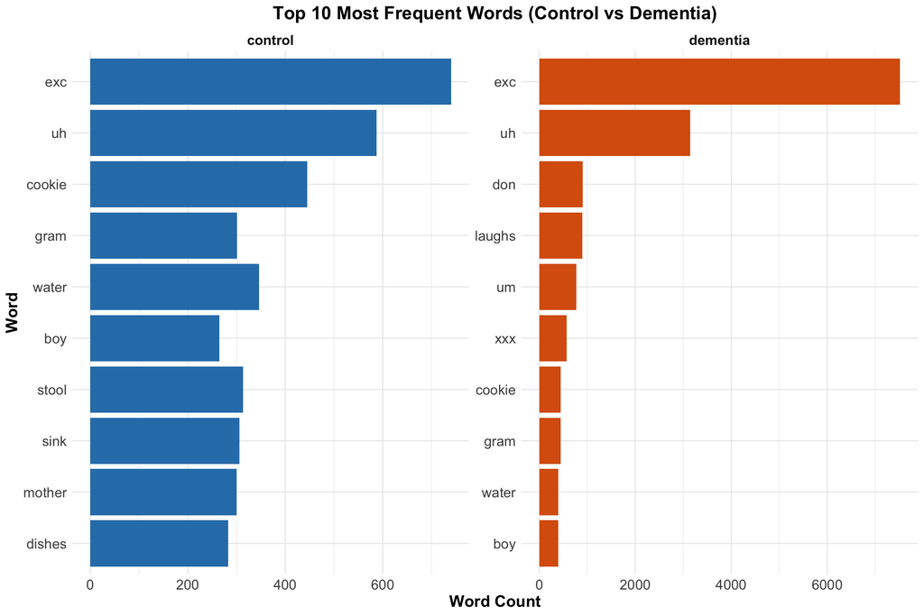

```r
# define common text styling for publication-quality plots
common_plot_theme <- theme_minimal() +                                   # start with minimal theme
  theme(
    axis.text = element_text(size = 13),                                 # increase axis text size
    axis.title = element_text(size = 15, face = "bold"),                # increase axis title size
    plot.title = element_text(size = 17, face = "bold", hjust = 0.5),   # center and bold titles
    strip.text = element_text(size = 13, face = "bold")                 # improve facet label readability
  )

# compute word counts by group from stopword-removed tokens
word_counts <- tokens_nostop %>%
  count(group, word, sort = TRUE)                                       # count words in each group

# build top words dataset by group
top_words <- word_counts %>%
  group_by(group) %>%                                                    # process each group separately
  slice_max(order_by = n, n = 10, with_ties = FALSE) %>%                # keep top 10 words per group
  ungroup() %>%                                                          # remove grouping
  filter(!is.na(group), !is.na(word))                                   # keep valid facet and term values

# create top words plot only when data is available
if (nrow(top_words) > 0 && n_distinct(top_words$group) > 0) {
  top_words_plot <- ggplot(top_words, aes(x = reorder(word, n), y = n, fill = group)) +
    geom_col(show.legend = FALSE) +                                     # draw bars
    coord_flip() +                                                      # flip axes for readability
    facet_wrap(~group, scales = "free") +                              # facet by group with free scales
    labs(
      title = "Top 10 Most Frequent Words (Control vs Dementia)",       # use clear publication title
      x = "Word",                                                       # set x-axis label
      y = "Word Count"                                                  # set y-axis label
    ) +
    scale_fill_manual(values = c("control" = "#2C7FB8", "dementia" = "#D95F0E")) +  # set consistent colors
    common_plot_theme                                                   # apply common formatting

  print(top_words_plot)                                                 # print top words plot
} else {
  message("Top words plot skipped: no valid data to facet.")
}
```

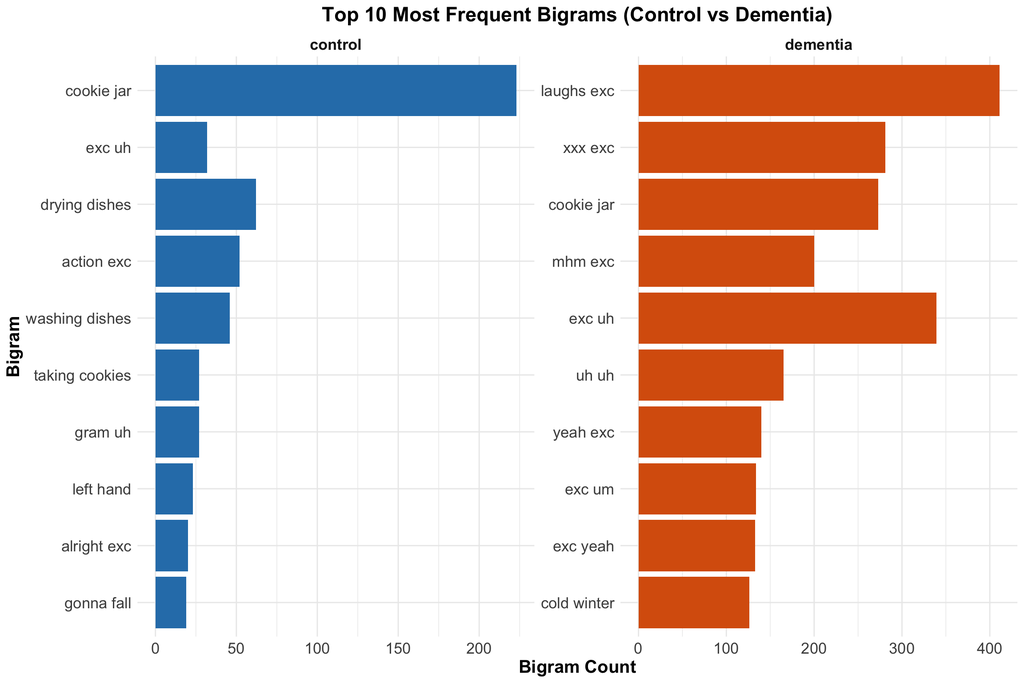

```r
# build top bigrams dataset by group
top_bigrams <- bigram_counts %>%
  group_by(group) %>%                                                    # process each group separately
  slice_max(order_by = n, n = 10, with_ties = FALSE) %>%                # keep top 10 bigrams per group
  ungroup() %>%                                                          # remove grouping
  filter(!is.na(group), !is.na(bigram))                                 # keep valid facet and term values

# create top bigrams plot only when data is available
if (nrow(top_bigrams) > 0 && n_distinct(top_bigrams$group) > 0) {
  top_bigrams_plot <- ggplot(top_bigrams, aes(x = reorder(bigram, n), y = n, fill = group)) +
    geom_col(show.legend = FALSE) +                                     # draw bars
    coord_flip() +                                                      # flip axes for readability
    facet_wrap(~group, scales = "free") +                              # facet by group with free scales
    labs(
      title = "Top 10 Most Frequent Bigrams (Control vs Dementia)",     # use clear publication title
      x = "Bigram",                                                     # set x-axis label
      y = "Bigram Count"                                                # set y-axis label
    ) +
    scale_fill_manual(values = c("control" = "#2C7FB8", "dementia" = "#D95F0E")) +  # set consistent colors
    common_plot_theme                                                   # apply common formatting

  print(top_bigrams_plot)                                               # print top bigrams plot
} else {
  message("Top bigrams plot skipped: no valid data to facet.")
}
```

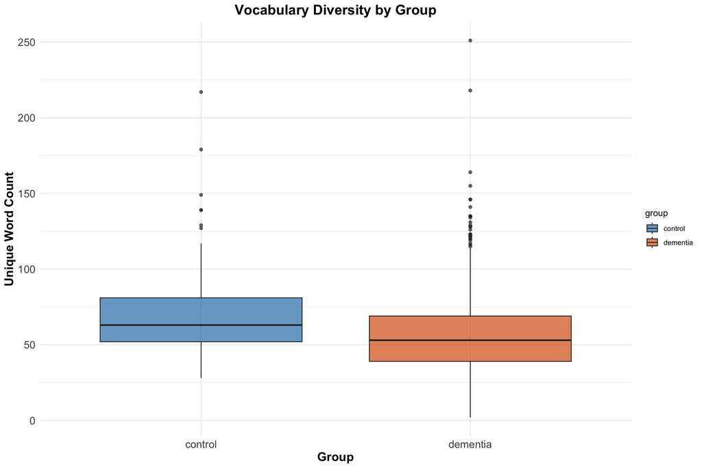

```r
# create unique words boxplot only when data exists
if (nrow(features_df) > 0 && n_distinct(features_df$group) > 0) {
  unique_words_plot <- ggplot(features_df, aes(x = group, y = unique_words, fill = group)) +
    geom_boxplot(alpha = 0.7) +                                         # draw boxplot for unique words
    labs(
      title = "Vocabulary Diversity by Group",                          # use clear publication title
      x = "Group",                                                      # set x-axis label
      y = "Unique Word Count"                                           # set y-axis label
    ) +
    scale_fill_manual(values = c("control" = "#2C7FB8", "dementia" = "#D95F0E")) +  # set consistent colors
    common_plot_theme                                                   # apply common formatting

  print(unique_words_plot)                                              # print unique words boxplot
} else {
  message("Unique words boxplot skipped: no valid data.")
}
```

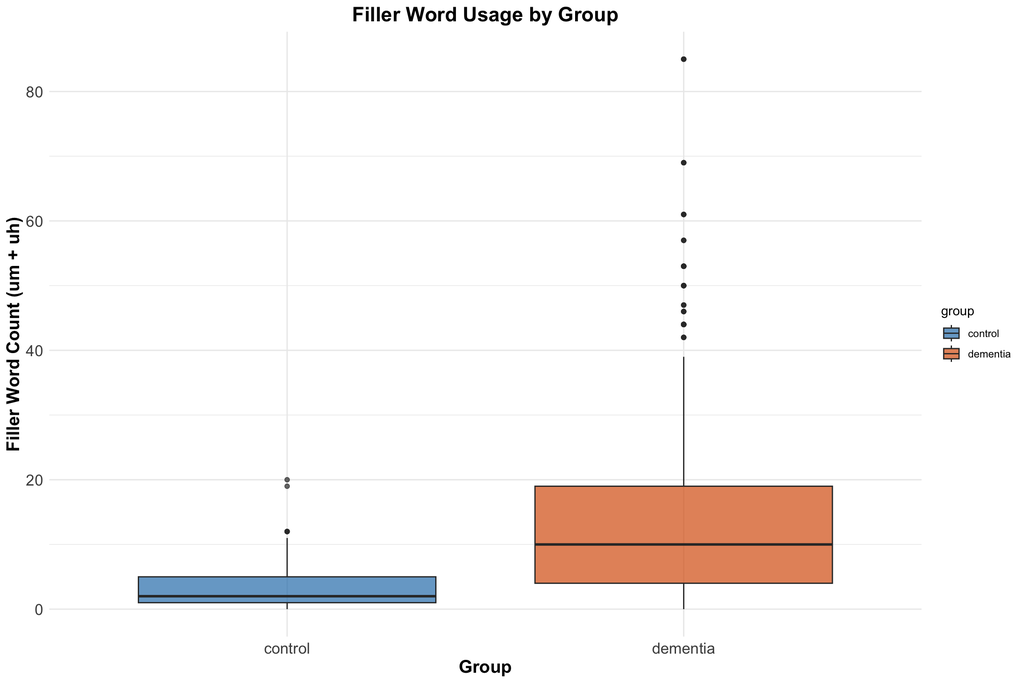

```r
# create filler count boxplot only when data exists
if (nrow(features_df) > 0 && n_distinct(features_df$group) > 0) {
  filler_count_plot <- ggplot(features_df, aes(x = group, y = filler_count, fill = group)) +
    geom_boxplot(alpha = 0.7) +                                         # draw boxplot for filler counts
    labs(
      title = "Filler Word Usage by Group",                             # use clear publication title
      x = "Group",                                                      # set x-axis label
      y = "Filler Word Count (um + uh)"                                 # set y-axis label
    ) +
    scale_fill_manual(values = c("control" = "#2C7FB8", "dementia" = "#D95F0E")) +  # set consistent colors
    common_plot_theme                                                   # apply common formatting

  print(filler_count_plot)                                              # print filler count boxplot
} else {
  message("Filler count boxplot skipped: no valid data.")
}
```

```r
# print short interpretation for plot section
if (nrow(feature_means) == 2) {
  control_unique <- feature_means %>% filter(group == "control") %>% pull(mean_unique_words)  # get control unique mean
  dementia_unique <- feature_means %>% filter(group == "dementia") %>% pull(mean_unique_words)  # get dementia unique mean
  control_filler <- feature_means %>% filter(group == "control") %>% pull(mean_filler_count)  # get control filler mean
  dementia_filler <- feature_means %>% filter(group == "dementia") %>% pull(mean_filler_count)  # get dementia filler mean

  cat("\nPlot interpretation:\n")                                        # print header line
  if (dementia_unique < control_unique) {                                # compare unique word means
    cat("The vocabulary plot suggests lower vocabulary diversity in the dementia group.\n")  # simple interpretation
  } else {
    cat("The vocabulary plot does not show lower vocabulary diversity for the dementia group.\n")  # simple interpretation
  }

  if (dementia_filler > control_filler) {                                # compare filler means
    cat("The filler plot suggests more filler words in the dementia group.\n")  # simple interpretation
  } else {
    cat("The filler plot does not suggest more filler words in the dementia group.\n")  # simple interpretation
  }
}
```

```
##
## Plot interpretation:
## The vocabulary plot suggests lower vocabulary diversity in the dementia group.
## The filler plot suggests more filler words in the dementia group.
```

## 8. Statistical Tests

This section runs the requested t-tests only when both groups are present and have enough observations.

```r
# create a helper function for safe two-group t-tests
safe_t_test <- function(data, formula_obj) {
  # keep only target groups for testing
  test_data <- data %>%
    filter(group %in% c("control", "dementia")) %>%                  # keep two comparison groups
    mutate(group = factor(group))                                       # convert group to factor

  # count rows per group
  group_counts <- test_data %>%
    count(group)

  # return message when group structure is invalid
  if (nrow(group_counts) != 2 || any(group_counts$n < 2)) {
    return("T-test skipped: both groups must exist with at least 2 files each.")
  }

  # run t-test when checks pass
  t.test(formula_obj, data = test_data)
}

# run t-test for unique words by group
ttest_unique <- safe_t_test(features_df, unique_words ~ group)

# run t-test for filler count by group
ttest_filler <- safe_t_test(features_df, filler_count ~ group)

# run t-test for TTR by group
ttest_ttr <- safe_t_test(features_df, TTR ~ group)

# define helper function for manual Cohen's d
compute_cohens_d <- function(data, outcome_col) {
  control_vals <- data %>%                                              # collect control values
    filter(group == "control") %>%                                      # keep control rows
    pull({{ outcome_col }})                                             # pull numeric outcome vector

  dementia_vals <- data %>%                                             # collect dementia values
    filter(group == "dementia") %>%                                     # keep dementia rows
    pull({{ outcome_col }})                                             # pull numeric outcome vector

  if (length(control_vals) < 2 || length(dementia_vals) < 2) {          # check minimum sample size
    return(NA_real_)                                                    # return NA when effect size cannot be computed
  }

  mean_control <- mean(control_vals, na.rm = TRUE)                      # compute control mean
  mean_dementia <- mean(dementia_vals, na.rm = TRUE)                    # compute dementia mean
  sd_control <- sd(control_vals, na.rm = TRUE)                          # compute control standard deviation
  sd_dementia <- sd(dementia_vals, na.rm = TRUE)                        # compute dementia standard deviation
  n_control <- sum(!is.na(control_vals))                                # count non-missing control values
  n_dementia <- sum(!is.na(dementia_vals))                              # count non-missing dementia values

  pooled_sd <- sqrt(((n_control - 1) * sd_control^2 + (n_dementia - 1) * sd_dementia^2) / (n_control + n_dementia - 2))  # compute pooled SD

  if (is.na(pooled_sd) || pooled_sd == 0) {                             # guard against invalid pooled SD
    return(NA_real_)                                                    # return NA when denominator is invalid
  }

  (mean_dementia - mean_control) / pooled_sd                            # return Cohen's d with dementia-control direction
}

# compute Cohen's d for unique words
cohens_d_unique <- compute_cohens_d(features_df, unique_words)

# compute Cohen's d for filler count
cohens_d_filler <- compute_cohens_d(features_df, filler_count)

# compute Cohen's d for TTR
cohens_d_ttr <- compute_cohens_d(features_df, TTR)

# print labeled result for vocabulary diversity test
cat("\nT-test result: unique_words ~ group\n")
```

```
##
## T-test result: unique_words ~ group
```

```r
print(ttest_unique)
```

```
##
##  Welch Two Sample t-test
##
## data:  unique_words by group
## t = 6.7819, df = 375.26, p-value = 4.626e-11
## alternative hypothesis: true difference in means between group control and group dementia is not equal to 0
## 95 percent confidence interval:
##   8.483049 15.410640
## sample estimates:
##  mean in group control mean in group dementia
##               68.02834               56.08150
```

```r
# print labeled result for filler usage test
cat("\nT-test result: filler_count ~ group\n")
```

```
##
## T-test result: filler_count ~ group
```

```r
print(ttest_filler)
```

```
##
##  Welch Two Sample t-test
##
## data:  filler_count by group
## t = -23.04, df = 1285.3, p-value < 2.2e-16
## alternative hypothesis: true difference in means between group control and group dementia is not equal to 0
## 95 percent confidence interval:
##  -11.494880  -9.690955
## sample estimates:
##  mean in group control mean in group dementia
##               3.283401              13.876318
```

```r
# print labeled result for TTR test
cat("\nT-test result: TTR ~ group\n")
```

```
##
## T-test result: TTR ~ group
```

```r
print(ttest_ttr)
```

```
##
##  Welch Two Sample t-test
##
## data:  TTR by group
## t = -0.14947, df = 530.73, p-value = 0.8812
## alternative hypothesis: true difference in means between group control and group dementia is not equal to 0
## 95 percent confidence interval:
##  -0.01432692  0.01230091
## sample estimates:
##  mean in group control mean in group dementia
##              0.5816819              0.5826949
```

```r
# print effect size summary
cat("\nEffect size (Cohen's d, dementia - control):\n")
```

```
##
## Effect size (Cohen's d, dementia - control):
```

```r
cat("Unique words d =", round(cohens_d_unique, 3), "\n")
```

```
## Unique words d = -0.476
```

```r
cat("Filler count d =", round(cohens_d_filler, 3), "\n")
```

```
## Filler count d = 0.885
```

```r
cat("TTR d =", round(cohens_d_ttr, 3), "\n")
```

```
## TTR d = 0.008
```

```r
# print short interpretation for statistical section
if (inherits(ttest_unique, "htest")) {
  if (ttest_unique$p.value < 0.05) {
    cat("Unique words are significantly different between groups.\n")
  } else {
    cat("Unique words are not significantly different between groups.\n")
  }
}
```

```
## Unique words are significantly different between groups.
```

```r
if (inherits(ttest_filler, "htest")) {
  if (ttest_filler$p.value < 0.05) {
    cat("Filler word use is significantly different between groups.\n")
  } else {
    cat("Filler word use is not significantly different between groups.\n")
  }
}
```

```
## Filler word use is significantly different between groups.
```

```r
if (inherits(ttest_ttr, "htest")) {
  if (ttest_ttr$p.value < 0.05) {
    cat("Type-token ratio is significantly different between groups.\n")
  } else {
    cat("Type-token ratio is not significantly different between groups.\n")
  }
}
```

```
## Type-token ratio is not significantly different between groups.
```

## 9. Output

This section prints final outputs including feature table, group summary statistics, and top frequency tables.

```r
# print full feature dataframe
features_df
```

```
## # A tibble: 1,290 × 7
##    file_name group    task     total_words unique_words filler_count   TTR
##    <chr>     <chr>    <chr>          <int>        <int>        <int> <dbl>
##  1 001-0.cha dementia cookie           106           58           18 0.547
##  2 001-0.cha dementia fluency          195          102           18 0.523
##  3 001-0.cha dementia sentence          32           25           18 0.781
##  4 001-2.cha dementia cookie           169           78           39 0.462
##  5 001-2.cha dementia fluency          319           94           39 0.295
##  6 001-2.cha dementia recall           566          135           39 0.239
##  7 001-2.cha dementia sentence          98           53           39 0.541
##  8 002-0.cha control  cookie           162           89            5 0.549
##  9 002-1.cha control  cookie           112           57            0 0.509
## 10 002-2.cha control  cookie           166           89            7 0.536
## # ℹ 1,280 more rows
```

```r
# compute descriptive statistics table per group
summary_stats <- features_df %>%
  group_by(group) %>%                                                   # summarize by group
  summarise(
    n_files = n(),                                                      # count files per group
    mean_total_words = mean(total_words, na.rm = TRUE),                # mean of total words
    median_total_words = median(total_words, na.rm = TRUE),            # median of total words
    sd_total_words = sd(total_words, na.rm = TRUE),                    # standard deviation of total words
    min_total_words = min(total_words, na.rm = TRUE),                  # minimum total words
    max_total_words = max(total_words, na.rm = TRUE),                  # maximum total words
    mean_unique_words = mean(unique_words, na.rm = TRUE),              # mean of unique words
    median_unique_words = median(unique_words, na.rm = TRUE),          # median of unique words
    sd_unique_words = sd(unique_words, na.rm = TRUE),                  # standard deviation of unique words
    min_unique_words = min(unique_words, na.rm = TRUE),                # minimum unique words
    max_unique_words = max(unique_words, na.rm = TRUE),                # maximum unique words
    mean_filler_count = mean(filler_count, na.rm = TRUE),              # mean of filler count
    median_filler_count = median(filler_count, na.rm = TRUE),          # median of filler count
    sd_filler_count = sd(filler_count, na.rm = TRUE),                  # standard deviation of filler count
    min_filler_count = min(filler_count, na.rm = TRUE),                # minimum filler count
    max_filler_count = max(filler_count, na.rm = TRUE),                # maximum filler count
    mean_TTR = mean(TTR, na.rm = TRUE),                                # mean of TTR
    median_TTR = median(TTR, na.rm = TRUE),                            # median of TTR
    sd_TTR = sd(TTR, na.rm = TRUE),                                    # standard deviation of TTR
    min_TTR = min(TTR, na.rm = TRUE),                                  # minimum TTR
    max_TTR = max(TTR, na.rm = TRUE),                                  # maximum TTR
    .groups = "drop"                                                   # remove grouping
  )

# print summary table
summary_stats
```

```
## # A tibble: 2 × 22
##   group    n_files mean_total_words median_total_words sd_total_words
##   <chr>      <int>            <dbl>              <int>          <dbl>
## 1 control      247             124.                110           62.7
## 2 dementia    1043             107.                 91           73.9
## # ℹ 17 more variables: min_total_words <int>, max_total_words <int>,
## #   mean_unique_words <dbl>, median_unique_words <int>, sd_unique_words <dbl>,
## #   min_unique_words <int>, max_unique_words <int>, mean_filler_count <dbl>,
## #   median_filler_count <int>, sd_filler_count <dbl>, min_filler_count <int>,
## #   max_filler_count <int>, mean_TTR <dbl>, median_TTR <dbl>, sd_TTR <dbl>,
## #   min_TTR <dbl>, max_TTR <dbl>
```

```r
# print top words table if available
if (exists("top_words") && nrow(top_words) > 0) {
  top_words
} else {
  message("Top words table not available.")
}
```

```
## # A tibble: 20 × 3
##    group    word       n
##    <chr>    <chr>  <int>
##  1 control  exc      740
##  2 control  uh       587
##  3 control  cookie   445
##  4 control  water    346
##  5 control  stool    313
##  6 control  sink     306
##  7 control  gram     301
##  8 control  mother   300
##  9 control  dishes   283
## 10 control  boy      265
## 11 dementia exc     7518
## 12 dementia uh      3144
## 13 dementia don      903
## 14 dementia laughs   900
## 15 dementia um       775
## 16 dementia xxx      568
## 17 dementia cookie   446
## 18 dementia gram     444
## 19 dementia boy      398
## 20 dementia water    398
```

```r
# print top bigrams table if available
if (exists("top_bigrams") && nrow(top_bigrams) > 0) {
  top_bigrams
} else {
  message("Top bigrams table not available.")
}
```

```
## # A tibble: 20 × 3
##    group    bigram             n
##    <chr>    <chr>          <int>
##  1 control  cookie jar       223
##  2 control  drying dishes     62
##  3 control  action exc        52
##  4 control  washing dishes    46
##  5 control  exc uh            32
##  6 control  gram uh           27
##  7 control  taking cookies    27
##  8 control  left hand         23
##  9 control  alright exc       20
## 10 control  gonna fall        19
## 11 dementia laughs exc       411
## 12 dementia exc uh           339
## 13 dementia xxx exc          281
## 14 dementia cookie jar       273
## 15 dementia mhm exc          200
## 16 dementia uh uh            165
## 17 dementia yeah exc         140
## 18 dementia exc um           134
## 19 dementia exc yeah         133
## 20 dementia cold winter      126
```

## 10. Final Narrative Summary of Results

```r
# generate a detailed descriptive summary of all results in plain language

if (nrow(feature_means) == 2) {

  # extract group means for readability
  control_unique <- feature_means %>% filter(group == "control") %>% pull(mean_unique_words)
  dementia_unique <- feature_means %>% filter(group == "dementia") %>% pull(mean_unique_words)

  control_filler <- feature_means %>% filter(group == "control") %>% pull(mean_filler_count)
  dementia_filler <- feature_means %>% filter(group == "dementia") %>% pull(mean_filler_count)

  control_ttr <- feature_means %>% filter(group == "control") %>% pull(mean_TTR)
  dementia_ttr <- feature_means %>% filter(group == "dementia") %>% pull(mean_TTR)

  cat("\n================ FINAL SUMMARY OF RESULTS ================\n\n")

  # vocabulary interpretation
  cat("Vocabulary Diversity:\n")
  cat("The control group produced an average of", round(control_unique, 2), "unique words per transcript, while the dementia group produced an average of", round(dementia_unique, 2), "unique words.\n")

  if (dementia_unique < control_unique) {
    cat("This suggests that individuals with Alzheimer’s disease use a more limited vocabulary compared to healthy controls, indicating reduced lexical diversity.\n\n")
  } else {
    cat("This suggests that vocabulary diversity is similar or higher in the dementia group in this dataset.\n\n")
  }

  # filler interpretation
  cat("Filler Word Usage (um, uh):\n")
  cat("The control group used an average of", round(control_filler, 2), "filler words per transcript, while the dementia group used an average of", round(dementia_filler, 2), ".\n")

  if (dementia_filler > control_filler) {
    cat("This indicates that individuals with Alzheimer’s disease rely more on filler words, which may reflect hesitation, word-finding difficulty, or reduced fluency.\n\n")
  } else {
    cat("This indicates that filler word usage is not higher in the dementia group in this dataset.\n\n")
  }

  # TTR interpretation
  cat("Type-Token Ratio (TTR):\n")
  cat("The average TTR for the control group is", round(control_ttr, 3), "while the dementia group has an average TTR of", round(dementia_ttr, 3), ".\n")

  if (dementia_ttr < control_ttr) {
    cat("This suggests that the dementia group shows more repetition in language, using the same words more frequently.\n\n")
  } else {
    cat("This suggests that repetition levels are similar or lower in the dementia group in this dataset.\n\n")
  }

  # statistical interpretation
  cat("Statistical Tests:\n")

  if (inherits(ttest_unique, "htest")) {
    cat("For unique words, the p-value is", round(ttest_unique$p.value, 4), ". ")
    if (ttest_unique$p.value < 0.05) {
      cat("This indicates a statistically significant difference between groups.\n")
    } else {
      cat("This indicates no statistically significant difference between groups.\n")
    }
  }

  if (inherits(ttest_filler, "htest")) {
    cat("For filler words, the p-value is", round(ttest_filler$p.value, 4), ". ")
    if (ttest_filler$p.value < 0.05) {
      cat("This indicates a statistically significant difference between groups.\n")
    } else {
      cat("This indicates no statistically significant difference between groups.\n")
    }
  }

  if (inherits(ttest_ttr, "htest")) {
    cat("For TTR, the p-value is", round(ttest_ttr$p.value, 4), ". ")
    if (ttest_ttr$p.value < 0.05) {
      cat("This indicates a statistically significant difference between groups.\n\n")
    } else {
      cat("This indicates no statistically significant difference between groups.\n\n")
    }
  }

  # effect size interpretation
  cat("Effect Sizes (Cohen’s d):\n")
  cat("Unique words d =", round(cohens_d_unique, 3), "\n")
  cat("Filler words d =", round(cohens_d_filler, 3), "\n")
  cat("TTR d =", round(cohens_d_ttr, 3), "\n")

  cat("Effect sizes help show how large the differences are between groups.\n")
  cat("Values around 0.2 are small, around 0.5 are moderate, and above 0.8 are large differences.\n\n")

  # overall conclusion
  cat("Overall Interpretation:\n")

  if (dementia_unique < control_unique && dementia_filler > control_filler) {
    cat("Overall, the results support the hypothesis that individuals with Alzheimer’s disease use simpler and more repetitive language. They show reduced vocabulary diversity and increased filler word usage.\n")
  } else {
    cat("Overall, the results provide partial or weak support for the hypothesis. Some expected patterns are not strongly observed in this dataset.\n")
  }

  cat("\n=========================================================\n")
}
```

[output not shown]